# Kickstarter Campaign Analytics

The dataset has been sourced from https://webrobots.io/kickstarter-datasets/. The data has been scraped by a professional web scraping service on a monthly basis. Each monthly dataset consists of multiple csv file zipped together and in total has approx. 200,000 rows and 41 columns. For this coursework, datasets from January 2020 to October 2020 will be used. As each dataset is quite huge and factoring in computation resource limitations, each dataset will be randomly sampled and combined into a larger dataset.

## 1. Data Wrangling and Processing

Instead of unzipping files and extracting over 60 csv files from each zipped folder, python can be used to automate this process. 'file_dir' consists of the file names of each dataset used in this coursework.

```python
#file_dir contains the names of each monthly dataset
file_dir = [
    'Kickstarter_2020-01-16T03_20_15_556Z.zip',
    'Kickstarter_2020-02-13T03_20_04_893Z.zip',
    'Kickstarter_2020-03-12T03_20_06_551Z.zip',
    'Kickstarter_2020-04-16T03_20_04_541Z.zip',
    'Kickstarter_2020-05-14T03_20_08_560Z.zip',
    'Kickstarter_2020-06-18T03_20_07_487Z.zip',
    'Kickstarter_2020-07-16T03_20_08_086Z.zip',
    'Kickstarter_2020-08-13T03_20_17_470Z.zip',
    'Kickstarter_2020-09-17T03_20_18_143Z.zip',
    'Kickstarter_2020-10-15T03_20_03_128Z.zip'
]
```

Using ZipFile, each dataset will be unzipped and processed. Each dataset is randomly sampled and 30% of each dataset will make up the coursework dataset.

```python
from zipfile import ZipFile
import pandas as pd
import matplotlib.pyplot as plt
import numpy as np

data_month_list = []

#Extract the CSV files from each zipped folder and randomly sample 30 percent of its contents. Store them in a list.
for file_name in file_dir:
    zipped_file = ZipFile(file_name)
    partial_data = {file.filename: pd.read_csv(zipped_file.open(file.filename)) for file in zipped_file.infolist()}
    data_month = pd.concat(partial_data, ignore_index = True)
    data_month_rand = data_month.sample(frac=0.3)
    data_month_list.append(data_month_rand)
```

```python
data = pd.concat(data_month_list, ignore_index = True)
data = data.drop_duplicates(subset='blurb', keep="last", ignore_index = True)
data.shape
```

```
(198689, 41)
```

The goal column needs to be converted into USD for standardisation. As there are campaigns from multiple countries, the static_usd_rate can be used to compute the equivalent goal amount in USD.

```python
data['goal_usd'] = data['static_usd_rate'] * data['goal']
```

```python
data.isnull().sum()
```

```
backers_count                    0
blurb                            1
category                         0
converted_pledged_amount         0
country                          0
country_displayable_name         0
created_at                       0
creator                          0
currency                         0
currency_symbol                  0
currency_trailing_code           0
current_currency                 0
deadline                         0
disable_communication            0
friends                     198447
fx_rate                          0
goal                             0
id                               0
is_backing                  198447
is_starrable                     0
is_starred                  198447
launched_at                      0
location                       207
name                             0
permissions                 198447
photo                            0
pledged                          0
profile                          0
slug                             0
source_url                       0
spotlight                        0
staff_pick                       0
state                            0
state_changed_at                 0
static_usd_rate                  0
urls                             0
usd_pledged                      0
usd_type                       343
last_update_published_at    198689
unread_messages_count       198689
unseen_activity_count       198689
goal_usd                         0
dtype: int64
```

```python
data.drop(columns = ['friends', 'is_backing', 'is_starred', 'permissions', 'currency_symbol', 'currency_trailing_code', 'photo', 'usd_type'], inplace = True)
```

To better capture the extent to which a campaign has performed, a new column 'raised_cap' will be included. This variable will be the excess capital raised over the goal amount. This will give an estimate of how well a campaign has performed. 'raised_percent' will capture the percentage increase.

```python
data['raised_cap'] = data['usd_pledged'] - data['goal_usd']
data['raised_cap'] = round(data['raised_cap'])

data['raised_percent'] = (round(data['usd_pledged']) / round(data['goal_usd'])) * 100
```

There are four states defining a campaign. It can be successful, a failure, cancelled, or live. A new column 'success' will capture this information. To avoid losing data points, success can be defined as meeting or exceeding the goal amount. A 1 will indicate success and a 0 will indicate failure. Since the reason for a cancelled campaign is not clear, instead of discarding those data points, the data can be classified according to the established criteria. Similarly, any live campaigns that have already exceeded their goal amounts will be included in the dataset. Campaigns that are live but have not yet reached their targets will be discarded due to uncertainty and no appropriate label.

```python
data.loc[data['state'] == 'successful', 'success'] = 1
data.loc[data['state'] == 'failed', 'success'] = 0
data.loc[((data['state'] == 'canceled') & (data['raised_cap'] >= 0)), 'success'] = 1
data.loc[((data['state'] == 'canceled') & (data['raised_cap'] < 0)), 'success'] = 0
data.loc[((data['state'] == 'live') & (data['raised_cap'] >= 0)), 'success'] = 1
```

Removing misclassified data. The data loss is miniscule.

```python
print("Data size before removing unexplainable points: ", data.shape[0])
if data[(data['raised_cap'] > 0) & (data['success'] == 0)].shape[0] > 0:
    data = data[~((data['raised_cap'] > 0) & (data['success'] == 0))]
if data[(data['raised_cap'] < 0) & (data['success'] == 1)].shape[0] > 0:
    data = data[~((data['raised_cap'] < 0) & (data['success'] == 1))]
print("Data size after removing unexplainable points: ", data.shape[0])
```

```
Data size before removing unexplainable points:  198689
Data size after removing unexplainable points:  198683
```

Replacing data points that are of the True or False form into a binary format of 1s and 0s.

```python
data['spotlight'].replace(to_replace = True, value = 1, inplace = True)
data['staff_pick'].replace(to_replace = True, value = 1, inplace = True)
data['is_starrable'].replace(to_replace = True, value = 1, inplace = True)
data['disable_communication'].replace(to_replace = True, value = 1, inplace = True)
```

Dropping useless columns that have too many null values. In this case pretty much the entire column is filled with NaNs.

```python
data.drop(columns = ['last_update_published_at', 'unread_messages_count', 'unseen_activity_count'], inplace = True)
```

Some columns have captured the time and date in the UNIX format. To be able to better read the data and categorise them, new columns are addded and the data is converted to readable dates and times using pandas 'to_datetime' function.

```python
data['created_at'] = pd.to_datetime(data['created_at'],unit='s')

data['deadline'] = pd.to_datetime(data['deadline'],unit='s')

data['launched_at'] = pd.to_datetime(data['launched_at'],unit='s')

data['state_changed_at'] = pd.to_datetime(data['state_changed_at'],unit='s')
```

To extract the city, main genres and sub genres from the category column, some regex text extraction needs to be done.

```python
data['sub_genre'] = data.category.str.extract("\"name\":\"([^\"]*)")

data['main_genre'] = data.category.str.extract("\"parent_name\":\"([^\"]*)")

data['location_city'] = data.location.str.extract("\"name\":\"([^\"]*)")
```

Dropping parent columns after useful information have been extracted

```python
data.drop(columns = ['category', 'location'], inplace = True)
```

These columns will be dropped as they are not valuable for analysis

```python
data.drop(columns = ['creator', 'profile', 'source_url', 'urls', 'state_changed_at', 'disable_communication'], inplace = True)
```

After extracting data into new columns, any null values will need to be dealt with. In this case, categorical data and labels will need to be discarded as the value cannot be imputed.

```python
data.isnull().sum()
```

```
backers_count                  0
blurb                          1
converted_pledged_amount       0
country                        0
country_displayable_name       0
created_at                     0
currency                       0
current_currency               0
deadline                       0
fx_rate                        0
goal                           0
id                             0
is_starrable                   0
launched_at                    0
name                           0
pledged                        0
slug                           0
spotlight                      0
staff_pick                     0
state                          0
static_usd_rate                0
usd_pledged                    0
goal_usd                       0
raised_cap                     0
raised_percent                 0
success                     5900
sub_genre                      0
main_genre                  9822
location_city                207
dtype: int64
```

```python
data = data.dropna()
```

Time information can be captured from the dataset. To look at how many days a campaign has been launched for or the days it took for development might be useful.

```python
data['launch_duration'] = data['deadline'].sub(data['launched_at'], axis = 0).dt.days
data['creation_time'] = data['launched_at'].sub(data['created_at'], axis = 0).dt.days
data['total_time'] = data['deadline'].sub(data['created_at'], axis = 0).dt.days
```

Initial data processing has been complete. A brief look at the statistics of the numerical data columns.

```python
data.describe()
```

|  | backers_count | converted_pledged_amount | fx_rate | goal | id | is_starrable | pledged | spotlight | staff_pick | static_usd_rate | usd_pledged | goal_usd | raised_cap | raised_percent | success | launch_duration | creation_time | total_time |
| --- | --- | --- | --- | --- | --- | --- | --- | --- | --- | --- | --- | --- | --- | --- | --- | --- | --- | --- |
| count | 183721.000000 | 1.837210e+05 | 183721.000000 | 1.837210e+05 | 1.837210e+05 | 183721.000000 | 1.837210e+05 | 183721.000000 | 183721.000000 | 183721.000000 | 1.837210e+05 | 1.837210e+05 | 1.837210e+05 | 1.837210e+05 | 183721.000000 | 183721.000000 | 183721.000000 | 183721.000000 |
| mean | 153.415576 | 1.369308e+04 | 0.989260 | 5.666546e+04 | 1.074294e+09 | 0.006325 | 2.602106e+04 | 0.537674 | 0.123606 | 1.003907 | 1.369319e+04 | 4.502188e+04 | -3.132870e+04 | inf | 0.545093 | 32.848858 | 48.208180 | 81.278036 |
| std | 982.986651 | 1.118235e+05 | 0.218993 | 1.332743e+06 | 6.191458e+08 | 0.079277 | 1.359298e+06 | 0.498580 | 0.329132 | 0.236840 | 1.118028e+05 | 1.228268e+06 | 1.232743e+06 | NaN | 0.497964 | 12.079469 | 137.021516 | 137.794254 |
| min | 0.000000 | 0.000000e+00 | 0.007993 | 1.000000e-02 | 1.852000e+04 | 0.000000 | 0.000000e+00 | 0.000000 | 0.000000 | 0.008771 | 0.000000e+00 | 1.000000e-02 | -1.523501e+08 | 0.000000e+00 | 0.000000 | 1.000000 | 0.000000 | 1.000000 |
| 25% | 3.000000 | 8.000000e+01 | 1.000000 | 1.500000e+03 | 5.378633e+08 | 0.000000 | 8.500000e+01 | 0.000000 | 0.000000 | 1.000000 | 8.000000e+01 | 1.500000e+03 | -5.000000e+03 | 1.520000e+00 | 0.000000 | 29.000000 | 2.000000 | 33.000000 |
| 50% | 24.000000 | 1.360000e+03 | 1.000000 | 5.000000e+03 | 1.074875e+09 | 0.000000 | 1.404000e+03 | 1.000000 | 0.000000 | 1.000000 | 1.360419e+03 | 5.000000e+03 | 2.400000e+01 | 1.009600e+02 | 1.000000 | 30.000000 | 11.000000 | 47.000000 |
| 75% | 88.000000 | 6.329000e+03 | 1.000000 | 1.500000e+04 | 1.610608e+09 | 0.000000 | 6.687000e+03 | 1.000000 | 0.000000 | 1.000000 | 6.335000e+03 | 1.365561e+04 | 7.750000e+02 | 1.250798e+02 | 1.000000 | 35.000000 | 37.000000 | 73.000000 |
| max | 105857.000000 | 1.296961e+07 | 9.970563 | 1.000000e+08 | 2.147476e+09 | 1.000000 | 4.816218e+08 | 1.000000 | 1.000000 | 1.716408 | 1.296961e+07 | 1.523501e+08 | 1.246961e+07 | inf | 1.000000 | 91.000000 | 2957.000000 | 3017.000000 |

## 2. Initial Data Exploration

To begin exploratory analysis, categorical data will be analysed. This will provide the big picture when detailed analysis is done at a later stage.

As expected, the US, Great Britain and Canada contributes the most number of campaigns

```
Top 10 Countries

       US     GB    CA    DE    FR    MX    IT    ES   NZ   NO
0  127873  20336  8679  3243  2610  2496  2430  2054  817  448
```

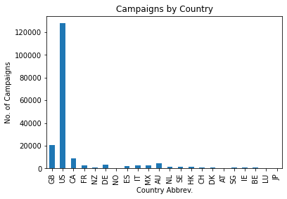

```python
from collections import Counter

country_count = Counter(data['country'])
fig_ctry = pd.DataFrame.from_dict(country_count, orient='index')
print("Top 10 Countries\n")
print(fig_ctry.head(10).T.sort_values(by = 0, axis = 1, ascending = False))
print("\n")
fig_ctry.plot(kind='bar')
plt.title("Campaigns by Country")
plt.xlabel("Country Abbrev.")
plt.ylabel("No. of Campaigns")
plt.legend().remove()
plt.show()
```

Spotlight refers to a web page that the creator can optionally provide in the campaign page. The spotlight web page tracks any past campaigns lead by the creator. This variable indicates whether the campaign is listed on the page and points to the credibility of the campaign creator. More than half of all campaigns are lsted on the creator's spotlight page.

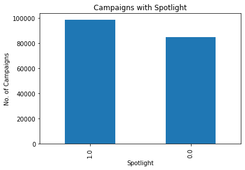

```python
spotlight_count = Counter(data['spotlight'])
fig_spot = pd.DataFrame.from_dict(spotlight_count, orient='index')
fig_spot.plot(kind='bar')
plt.title("Campaigns with Spotlight")
plt.xlabel("Spotlight")
plt.ylabel("No. of Campaigns")
plt.legend().remove()
plt.show()
```

```
Staff Picked Campaigns

      0.0    1.0
0  161012  22709
```

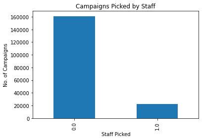

```python
staffpick_count = Counter(data['staff_pick'])
fig_staff = pd.DataFrame.from_dict(staffpick_count, orient='index')
print("Staff Picked Campaigns\n")
print(fig_staff.T)
print("\n")
fig_staff.plot(kind='bar')
plt.title("Campaigns Picked by Staff")
plt.xlabel("Staff Picked")
plt.ylabel("No. of Campaigns")
plt.legend().remove()
plt.show()
```

Contribution of campaigns by city. Los Angeles leads, with London a close second. American cities dominate this plot.

```
Top 5 Cities

                  0
Los Angeles    8342
London         7008
New York       6630
Chicago        3259
San Francisco  2793
```

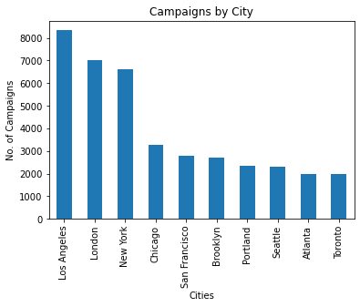

```python
city_count = Counter(data['location_city'])
fig_city = pd.DataFrame.from_dict(city_count, orient='index')
fig_city = fig_city.T.sort_values(by = 0, axis = 1, ascending = False)
print("Top 5 Cities\n")
print(fig_city.T.head())
print("\n")
top_cities = fig_city.T.head(10)
top_cities.plot(kind = 'bar')
plt.title("Campaigns by City")
plt.xlabel("Cities")
plt.ylabel("No. of Campaigns")
plt.legend().remove()
plt.show()
```

Number of campaigns sorted by subgenres. Games, Web, and Design are the three biggest subgenres.

```
Top 10 Sub Genres

                   0
Tabletop Games  3921
Web             3901
Product Design  3138
Comedy          2899
Illustration    2767
Comic Books     2682
Accessories     2653
Playing Cards   2625
Graphic Novels  2567
Apparel         2567
```

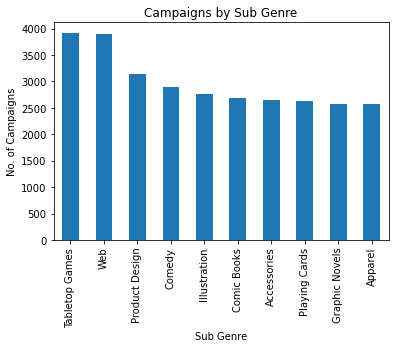

```python
subgenre_count = Counter(data['sub_genre'])
fig_subgenre = pd.DataFrame.from_dict(subgenre_count, orient='index')
fig_subgenre = fig_subgenre.T.sort_values(by = 0, axis = 1, ascending = False)
top_subgenre = fig_subgenre.T.head(10)
print("Top 10 Sub Genres\n")
print(top_subgenre)
print("\n")
top_subgenre.plot(kind = 'bar')
plt.title("Campaigns by Sub Genre")
plt.xlabel("Sub Genre")
plt.ylabel("No. of Campaigns")
plt.legend().remove()
plt.show()
```

Maingenres are more broad categories. Film, Music, and Technology are the three biggest maingenres.

```
Main Genres

                  0
Film & Video  25677
Music         25131
Technology    19715
Art           19317
Publishing    18935
Food          14471
Games         13645
Fashion       10679
Design         7398
Comics         7202
Photography    6015
Crafts         5283
Theater        4823
Journalism     3681
Dance          1749
```

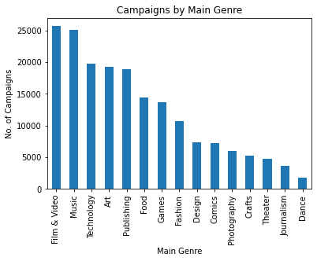

```python
maingenre_count = Counter(data['main_genre'])
fig_maingenre = pd.DataFrame.from_dict(maingenre_count, orient='index')
fig_maingenre = fig_maingenre.T.sort_values(by = 0, axis = 1, ascending = False)

print("Main Genres\n")
print(fig_maingenre.T)
print("\n")
fig_maingenre.T.plot(kind = 'bar')
plt.title("Campaigns by Main Genre")
plt.xlabel("Main Genre")
plt.ylabel("No. of Campaigns")
plt.legend().remove()
plt.show()
```

Campaigns by state. A few are live or cancelled.

```
States

                0
successful  98782
failed      75015
canceled     8744
live         1180
```

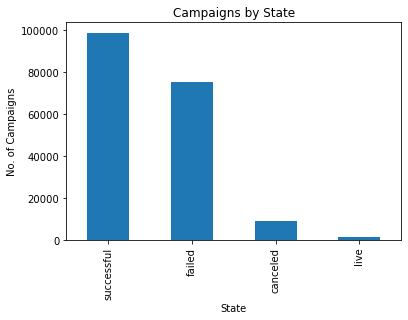

```python
state_count = Counter(data['state'])
fig_state = pd.DataFrame.from_dict(state_count, orient='index')
fig_state = fig_state.T.sort_values(by = 0, axis = 1, ascending = False)

print("States\n")
print(fig_state.T)
print("\n")
fig_state.T.plot(kind = 'bar')
plt.title("Campaigns by State")
plt.xlabel("State")
plt.ylabel("No. of Campaigns")
plt.legend().remove()
plt.show()
```

More than half of all campaigns have succeeded.

```
Campaign Success

          0
1.0  100145
0.0   83576
```

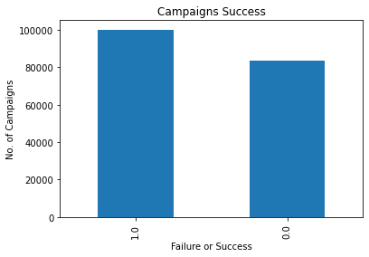

```python
state_success = Counter(data['success'])
fig_success = pd.DataFrame.from_dict(state_success, orient='index')
fig_success = fig_success.T.sort_values(by = 0, axis = 1, ascending = False)

print("Campaign Success\n")
print(fig_success.T)
print("\n")
fig_success.T.plot(kind = 'bar')
plt.title("Campaigns Success")
plt.xlabel("Failure or Success")
plt.ylabel("No. of Campaigns")
plt.legend().remove()
plt.show()
```

To remove outliers that can affect analysis, the goal amount will be analysed. From the calculations below, projects that have very high goal amounts fail 98 percent of the time. Goal amounts that are too high or too low can skew results and therefore will need to be evaluated.

```python
projects_above_1M_fail = data[(data['goal_usd'] >= 1000000) & (data['success'] == 0)].shape[0]
projects_above_1M_success = data[(data['goal_usd'] >= 1000000) & (data['success'] == 1)].shape[0]
print("Projects above $1M that succeeded: ", projects_above_1M_success)
print("Projects above $1M that failed: ", projects_above_1M_fail)
print("Percentage of succeeded projects: ", (projects_above_1M_success / (projects_above_1M_success + projects_above_1M_fail) * 100), "%")
print("Percentage of failed projects: ", (projects_above_1M_fail / (projects_above_1M_success + projects_above_1M_fail) * 100), "%")
```

```
Projects above $1M that succeeded:  11
Projects above $1M that failed:  665
Percentage of succeeded projects:  1.6272189349112427 %
Percentage of failed projects:  98.37278106508876 %
```

```python
data_numeric = data.select_dtypes(include = 'number')
data_numeric = data_numeric.drop(columns = ['converted_pledged_amount', 'fx_rate', 'id', 'pledged', 'static_usd_rate'])
```

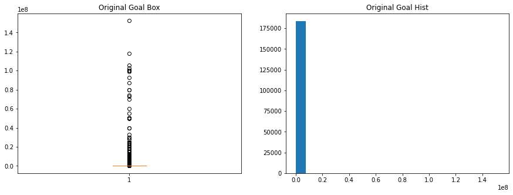

```
Mean:  45021.88477716302
Std:  1228267.9388239316
Median:  5000.0
LQR:  1500.0
UQR 13655.6056
IQR:  12155.6056
Normalised shape before removing inf:  183721
Normalised shape after removing inf:  183721
```

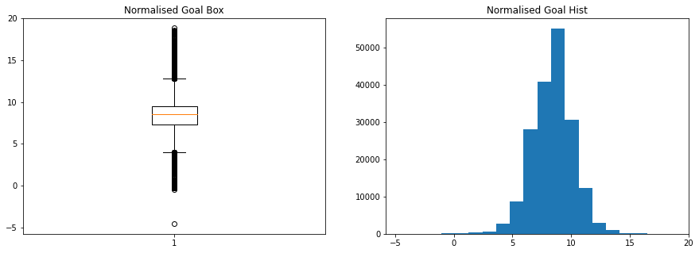

```
Shape of goal dataframe:  183721
Shape of goal dataframe after removing outliers:  181961
```

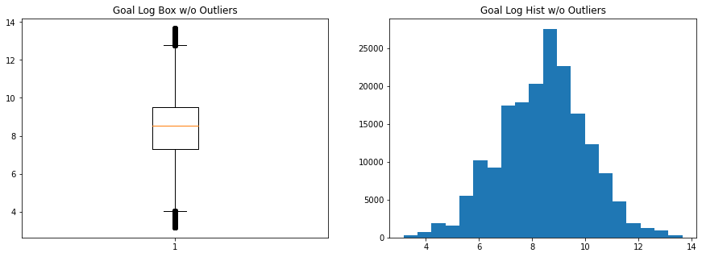

```
Mean:  17010.33252906435
Std:  48392.626648532954
Number of data points that are outliers:  1760
```

```python
#Plot histogram and boxplot for the relatively cleaned data
fig, axis = plt.subplots(1, 2, figsize=(15, 5))

axis[0].boxplot(data_numeric.goal_usd)
axis[0].set_title('Original Goal Box')
axis[1].hist(data_numeric.goal_usd, 20)
axis[1].set_title('Original Goal Hist')
plt.show()

#Do analysis on Goal using a seperate variable so that we don't modify the dataset yet
goal = data_numeric.goal_usd

goal_std = goal.std()
goal_mean = goal.mean()
goal_lqr = goal.quantile(0.25)
goal_uqr = goal.quantile(0.75)
goal_iqr = goal_uqr - goal_lqr
print("Mean: ", goal_mean)
print("Std: ", goal_std)
print("Median: ", goal.median())
print("LQR: ", goal_lqr)
print("UQR", goal_uqr)
print("IQR: ", goal_iqr)

#Data is heavily skewed. Apply log transform to see if we can get normal distribution
normalised = goal.apply(np.log)
print("Normalised shape before removing inf: ", normalised.shape[0])
normalised = normalised[np.isfinite(normalised)]
print("Normalised shape after removing inf: ", normalised.shape[0])

fig, axis = plt.subplots(1, 2, figsize=(15, 5))

axis[0].boxplot(normalised)
axis[0].set_title('Normalised Goal Box')
axis[1].hist(normalised, 20)
axis[1].set_title('Normalised Goal Hist')
plt.show()

#Create a new dataframe so that we can include the non-log data and the log transformed data
data_goal = pd.DataFrame(data['goal_usd'])

data_goal['normalised'] = data_goal['goal_usd'].apply(np.log)
data_goal = data_goal[np.isfinite(data_goal['normalised'])]

print("Shape of goal dataframe: ", data_goal.shape[0])

goal_std = data_goal['normalised'].std()
goal_mean = data_goal['normalised'].mean()
data_goal = data_goal[data_goal['normalised'] > (goal_mean - (3 * goal_std))]
data_goal = data_goal[data_goal['normalised'] < (goal_mean + (3 * goal_std))]

print("Shape of goal dataframe after removing outliers: ", data_goal.shape[0])

fig, axis = plt.subplots(1, 2, figsize=(15, 5))

axis[0].boxplot(data_goal['normalised'])
axis[0].set_title('Goal Log Box w/o Outliers')
axis[1].hist(data_goal['normalised'], 20)
axis[1].set_title('Goal Log Hist w/o Outliers')
plt.show()

print("Mean: ", data_goal['goal_usd'].mean())
print("Std: ", data_goal['goal_usd'].std())

print("Number of data points that are outliers: ", data_numeric.goal.shape[0] - data_goal.shape[0])
```

A QQ Plot needs to be plotted to ensure that the variable is normally distributed. As seen in the QQ plot below, the variable has tails at the edges, but for the most part lies on the normal line.

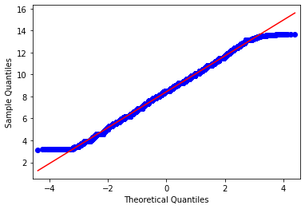

```python
import statsmodels.api as sm
from scipy import stats

fig = sm.qqplot(data_goal['normalised'], stats.norm, line = 'r')
plt.show()
```

Removing outliers from main data set

```python
data['goal_normalised'] = data['goal_usd'].apply(np.log)
data = data[np.isfinite(data['goal_normalised'])]

goal_std = data['goal_normalised'].std()
goal_mean = data['goal_normalised'].mean()
data = data[data['goal_normalised'] > (goal_mean - (3 * goal_std))]
data = data[data['goal_normalised'] < (goal_mean + (3 * goal_std))]
```

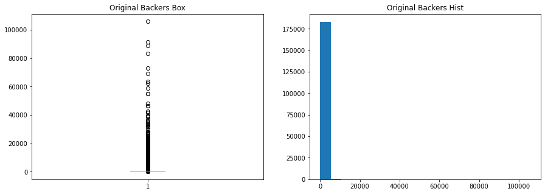

```
Mean:  153.4155757915535
Std:  982.9866507297994
Median:  24.0
LQR:  3.0
UQR 88.0
IQR:  85.0
Normalised shape before removing inf:  183721
Normalised shape after removing inf:  167740
```

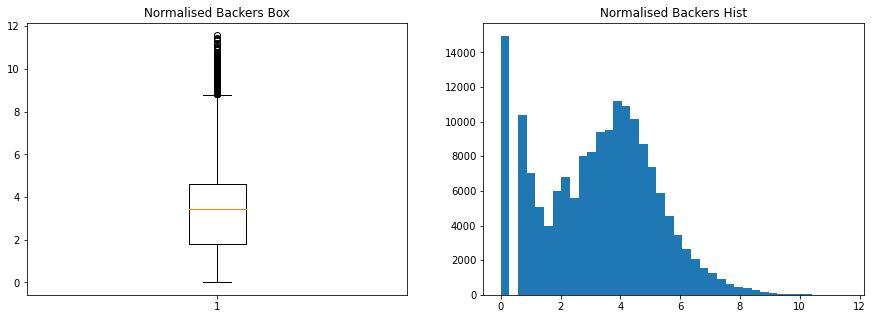

```python
#Plot histogram and boxplot for the relatively cleaned data
fig, axis = plt.subplots(1, 2, figsize=(15, 5))

axis[0].boxplot(data_numeric.backers_count)
axis[0].set_title('Original Backers Box')
axis[1].hist(data_numeric.backers_count, 20)
axis[1].set_title('Original Backers Hist')
plt.show()

#Do analysis on Backers Count using a seperate variable so that we don't modify the dataset yet
backers = data_numeric.backers_count

backers_std = backers.std()
backers_mean = backers.mean()
backers_lqr = backers.quantile(0.25)
backers_uqr = backers.quantile(0.75)
backers_iqr = backers_uqr - backers_lqr
print("Mean: ", backers_mean)
print("Std: ", backers_std)
print("Median: ", backers.median())
print("LQR: ", backers_lqr)
print("UQR", backers_uqr)
print("IQR: ", backers_iqr)

#Data is heavily skewed. Apply log transform to see if we can get normal distribution
normalised = backers.apply(np.log)
print("Normalised shape before removing inf: ", normalised.shape[0])
normalised = normalised[np.isfinite(normalised)]
print("Normalised shape after removing inf: ", normalised.shape[0])

fig, axis = plt.subplots(1, 2, figsize=(15, 5))

axis[0].boxplot(normalised)
axis[0].set_title('Normalised Backers Box')
axis[1].hist(normalised, 40)
axis[1].set_title('Normalised Backers Hist')
plt.show()
```

```python
data = data.reset_index(drop = True)
```

```python
data_pass = data[data['success'] == 1]
data_fail = data[data['success'] == 0]
```

As predicted earlier, when the backers count of successful campaigns is plotted, the distribution is quite normal. Log transformation sometimes yields infinities due to the presense of zeroes. The data can be shifted to avoid non-finite values.

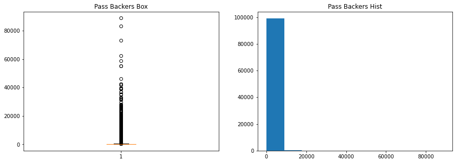

```
Normalised shape before removing inf:  99311
Normalised shape after removing inf:  99311
```

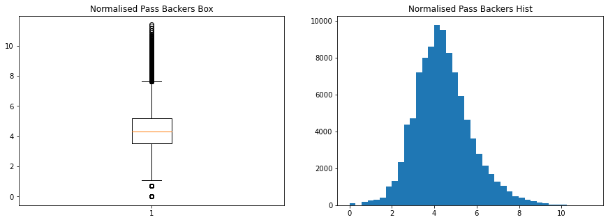

```python
fig, axis = plt.subplots(1, 2, figsize=(15, 5))

axis[0].boxplot(data_pass.backers_count)
axis[0].set_title('Pass Backers Box')
axis[1].hist(data_pass.backers_count)
axis[1].set_title('Pass Backers Hist')
plt.show()

#Data is heavily skewed. Apply log transform to see if we can get normal distribution
normalised = data_pass.backers_count.apply(np.log)
print("Normalised shape before removing inf: ", normalised.shape[0])
normalised = normalised[np.isfinite(normalised)]
print("Normalised shape after removing inf: ", normalised.shape[0])

fig, axis = plt.subplots(1, 2, figsize=(15, 5))

axis[0].boxplot(normalised)
axis[0].set_title('Normalised Pass Backers Box')
axis[1].hist(normalised, 40)
axis[1].set_title('Normalised Pass Backers Hist')
plt.show()
```

However, when looking at distributions of backers count associated with failed campaigns yields a very messy result. This is to be expected as many failed campaigns have zero or few backers. This reveals the presense of several modalities which is making the original data quite messy.

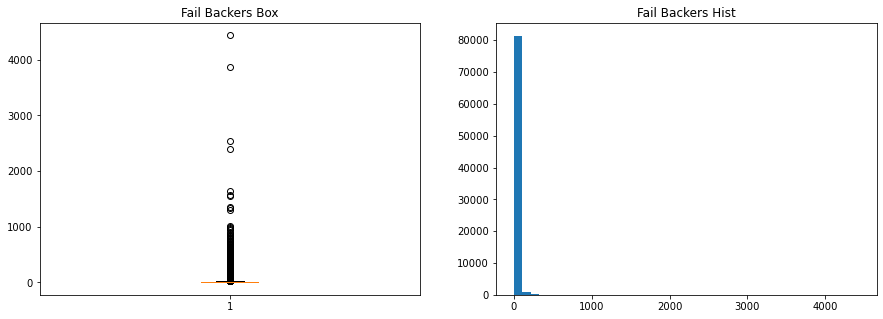

```
Normalised shape before removing inf:  82650
Normalised shape after removing inf:  67013
```

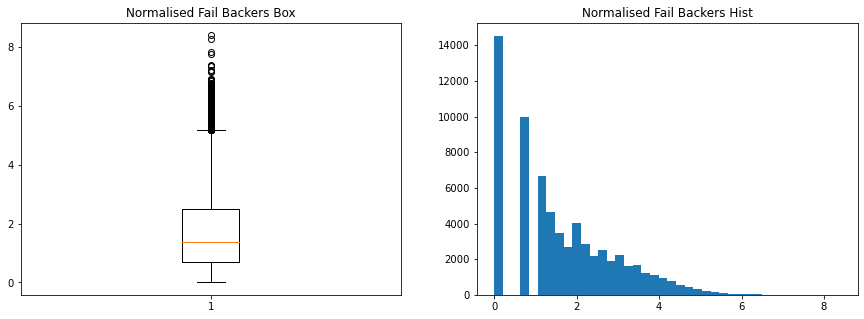

```python
fig, axis = plt.subplots(1, 2, figsize=(15, 5))

axis[0].boxplot(data_fail.backers_count)
axis[0].set_title('Fail Backers Box')
axis[1].hist(data_fail.backers_count, 40)
axis[1].set_title('Fail Backers Hist')
plt.show()

#Data is heavily skewed. Apply log transform to see if we can get normal distribution
normalised = data_fail.backers_count.apply(np.log)
#normalised = data_fail.backers_count.transform(np.sqrt)
#normalised = normalised.transform(np.reciprocal)
print("Normalised shape before removing inf: ", normalised.shape[0])
normalised = normalised[np.isfinite(normalised)]
print("Normalised shape after removing inf: ", normalised.shape[0])

fig, axis = plt.subplots(1, 2, figsize=(15, 5))

axis[0].boxplot(normalised)
axis[0].set_title('Normalised Fail Backers Box')
axis[1].hist(normalised, 40)
axis[1].set_title('Normalised Fail Backers Hist')
plt.show()
```

## 3. Detailed Data Exploration

To evaluate what features, variables, or metrics are important for a successful campaign, the data set will need to be split into successful and failed data sets (which has been done earlier). The detailed analysis will explore the impact some variables have on the outcome of a campaign.

To begin with, the proportion of countries that have high success rates needs to be evaluated. Hong Kong, Japan, Singapore, and Great Britain have some of the highest success rates. There is a caveat. The number of campaigns from countries other than the US or GB is quite low and therefore will need to be taken into account.

```
Proportion of Successful Projects by Country

    Pass Percent
HK     73.226950
JP     61.098398
SG     58.333333
GB     58.074351
US     55.429215
DK     51.798561
CA     51.411453
NZ     51.407589
FR     51.302682
LU     50.980392
SE     49.615385
```

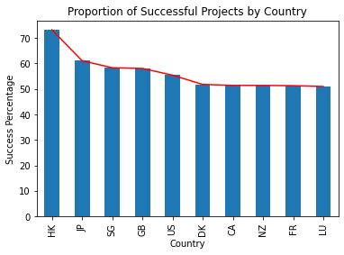

```python
country = fig_ctry.T.sort_values(by = 0, axis = 1, ascending = False)
country_count = Counter(data_pass['country'])
country_pass = pd.DataFrame.from_dict(country_count, orient='index')
country_pass = country_pass.T.sort_values(by = 0, axis = 1, ascending = False)
country_pass_percent = (country_pass / country) * 100
country_pass_percent = country_pass_percent.sort_values(by = 0, axis = 1, ascending = False)
country_pass_percent = country_pass_percent.T
country_pass_percent = country_pass_percent.rename(columns={0: "Pass Percent"})
print("Proportion of Successful Projects by Country\n")
print(country_pass_percent.head(11))
print("\n")
country_pass_percent.iloc[0:10].plot(kind='bar')
plt.plot(country_pass_percent.iloc[0:10], 'r')
plt.title("Proportion of Successful Projects by Country")
plt.legend().remove()
plt.xlabel("Country")
plt.ylabel("Success Percentage")
plt.show()
```

Subgenre performance

```
Proportion of Most Successful Projects by Subgenre

                  Pass Percent
Product Design       99.936265
Shorts               99.711578
Children's Books     99.687378
Country & Folk       99.626091
Documentary          99.619611


Proportion of Least Successful Projects by Subgenre

              Pass Percent
Web              14.098949
Mobile Games     13.462347
Bacon            13.333333
Video            13.141684
Food Trucks      12.713472
```

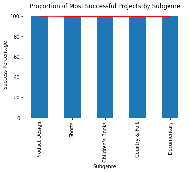

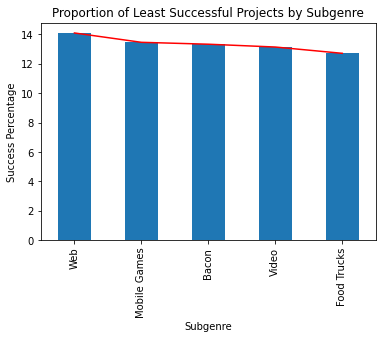

```python
subgenre = fig_subgenre
subgenre_count = Counter(data_pass['sub_genre'])
subgenre_pass = pd.DataFrame.from_dict(subgenre_count, orient='index')
subgenre_pass = subgenre_pass.T.sort_values(by = 0, axis = 1, ascending = False)
subgenre_pass_percent = (subgenre_pass / subgenre) * 100
subgenre_pass_percent = subgenre_pass_percent.sort_values(by = 0, axis = 1, ascending = False)
subgenre_pass_percent = subgenre_pass_percent.T
subgenre_pass_percent = subgenre_pass_percent.rename(columns={0: "Pass Percent"})

print("Proportion of Most Successful Projects by Subgenre\n")
print(subgenre_pass_percent.head())
print("\n")
print("Proportion of Least Successful Projects by Subgenre\n")
print(subgenre_pass_percent.iloc[-5:])
print("\n")

subgenre_pass_percent.iloc[0:5].plot(kind='bar')
plt.plot(subgenre_pass_percent.iloc[0:5], 'r')
plt.title("Proportion of Most Successful Projects by Subgenre")
plt.legend().remove()
plt.xlabel("Subgenre")
plt.ylabel("Success Percentage")
plt.show()

subgenre_pass_percent.iloc[-5:].plot(kind='bar')
plt.plot(subgenre_pass_percent.iloc[-5:], 'r')
plt.title("Proportion of Least Successful Projects by Subgenre")
plt.legend().remove()
plt.xlabel("Subgenre")
plt.ylabel("Success Percentage")
plt.show()
```

Maingenre Performance

```
Proportion of Most Successful Projects by Maingenre

            Pass Percent
Comics         82.129964
Games          68.215464
Publishing     67.509902
Music          64.836258
Design         62.611517


Proportion of Least Successful Projects by Maingenre

             Pass Percent
Technology      36.753741
Photography     33.283458
Food            26.611844
Crafts          25.307590
Journalism      20.809563
```

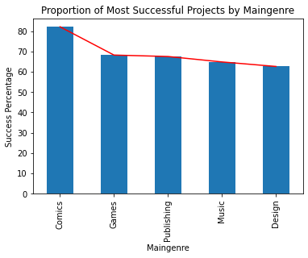

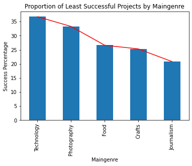

```python
maingenre = fig_maingenre
maingenre_count = Counter(data_pass['main_genre'])
maingenre_pass = pd.DataFrame.from_dict(maingenre_count, orient='index')
maingenre_pass = maingenre_pass.T.sort_values(by = 0, axis = 1, ascending = False)
maingenre_pass_percent = (maingenre_pass / maingenre) * 100
maingenre_pass_percent = maingenre_pass_percent.sort_values(by = 0, axis = 1, ascending = False)
maingenre_pass_percent = maingenre_pass_percent.T
maingenre_pass_percent = maingenre_pass_percent.rename(columns={0: "Pass Percent"})

print("Proportion of Most Successful Projects by Maingenre\n")
print(maingenre_pass_percent.head())
print("\n")
print("Proportion of Least Successful Projects by Maingenre\n")
print(maingenre_pass_percent.iloc[-5:])
print("\n")

maingenre_pass_percent.head().plot(kind = 'bar')
plt.plot(maingenre_pass_percent.head(), 'r')
plt.title("Proportion of Most Successful Projects by Maingenre")
plt.legend().remove()
plt.xlabel("Maingenre")
plt.ylabel("Success Percentage")
plt.show()

maingenre_pass_percent.iloc[-5:].plot(kind = 'bar')
plt.plot(maingenre_pass_percent.iloc[-5:], 'r')
plt.title("Proportion of Least Successful Projects by Maingenre")
plt.legend().remove()
plt.xlabel("Maingenre")
plt.ylabel("Success Percentage")
plt.show()
```

```python
print("Percentage of campaigns that are successful and are on spotlight: ", ((len(data[((data['success'] == 1) & (data['spotlight'] == 1))]) / len(data[data['success'] == 1])) * 100))
print("Percentage of campaigns that are successful and are staff picks: ", ((len(data[((data['success'] == 1) & (data['staff_pick'] == 1))]) / len(data[data['success'] == 1])) * 100))
```

```
Percentage of campaigns that are successful and are on spotlight:  98.66681435087754
Percentage of campaigns that are successful and are staff picks:  20.303893828478216
```

The following analysis deals with staff picked campaings that are successful and is categorised into main and sub genres. There is a huge mismatch when it comes to subgenres which could explain why staff picked capaigns aren't doing too well. Comparing successful subgenres with the ones picked by staff, it is easy to see the difference in interest. Staff picks tend to focus on artistic and social improvement campaigns.

```
Most Successful Campaign Maingenres Picked by Staff

              Pass Percent
Comics           24.618162
Dance            18.753573
Publishing       17.824135
Film & Video     11.960120
Games            11.777208
```

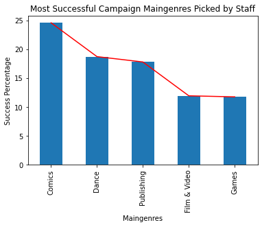

```python
staffgenre_count = Counter(data_pass.main_genre[data_pass['staff_pick'] == 1])
staffgenre_pass = pd.DataFrame.from_dict(staffgenre_count, orient='index')
staffgenre_pass = staffgenre_pass.T.sort_values(by = 0, axis = 1, ascending = False)
staffgenre_pass_percent = (staffgenre_pass / maingenre) * 100
staffgenre_pass_percent = staffgenre_pass_percent.sort_values(by = 0, axis = 1, ascending = False)
staffgenre_pass_percent = staffgenre_pass_percent.T
staffgenre_pass_percent = staffgenre_pass_percent.rename(columns={0: "Pass Percent"})

print("Most Successful Campaign Maingenres Picked by Staff\n")
print(staffgenre_pass_percent.head())
print("\n")

staffgenre_pass_percent.head().plot(kind = 'bar')
plt.plot(staffgenre_pass_percent.head(), 'r')
plt.title("Most Successful Campaign Maingenres Picked by Staff")
plt.legend().remove()
plt.xlabel("Maingenres")
plt.ylabel("Success Percentage")
plt.show()
```

```
Most Successful Campaign Subgenres Picked by Staff

                 Pass Percent
Typography          38.028169
Video Games         37.801932
Social Practice     33.766234
Documentary         32.544379
Letterpress         32.432432
```

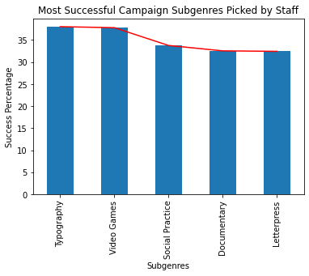

```python
staffgenre_count = Counter(data_pass.sub_genre[data_pass['staff_pick'] == 1])
staffgenre_pass = pd.DataFrame.from_dict(staffgenre_count, orient='index')
staffgenre_pass = staffgenre_pass.T.sort_values(by = 0, axis = 1, ascending = False)
staffgenre_pass_percent = (staffgenre_pass / subgenre) * 100
staffgenre_pass_percent = staffgenre_pass_percent.sort_values(by = 0, axis = 1, ascending = False)
staffgenre_pass_percent = staffgenre_pass_percent.T
staffgenre_pass_percent = staffgenre_pass_percent.rename(columns={0: "Pass Percent"})

print("Most Successful Campaign Subgenres Picked by Staff\n")
print(staffgenre_pass_percent.head())
print("\n")

staffgenre_pass_percent.head().plot(kind = 'bar')
plt.plot(staffgenre_pass_percent.head(), 'r')
plt.title("Most Successful Campaign Subgenres Picked by Staff")
plt.legend().remove()
plt.xlabel("Subgenres")
plt.ylabel("Success Percentage")
plt.show()
```

To understand how well campaigns perform, an analysis of the average raised capital for successul campaigns is needed. The data is categorised into main and sub genres, and it can be seen which genres are the most successful (campaings that beats their goal amount by a good margin).

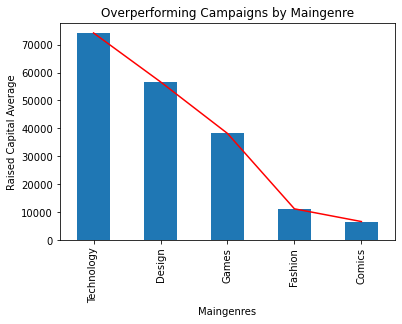

```python
i = {}

for col in maingenre.columns:
    i[col] = (data_pass.raised_cap[data_pass['main_genre'] == col].sum() / len(data_pass.raised_cap[data_pass['main_genre'] == col]))

raised_cap_prop = pd.DataFrame.from_dict(i, orient='index')
raised_cap_prop = raised_cap_prop.T.sort_values(by = 0, axis = 1, ascending = False)
raised_cap_prop = raised_cap_prop.T
raised_cap_prop = raised_cap_prop.rename(columns={0: "raised_cap_avg"})

raised_cap_prop.head().plot(kind = 'bar')
plt.plot(raised_cap_prop.head(), 'r')
plt.title("Overperforming Campaigns by Maingenre")
plt.legend().remove()
plt.xlabel("Maingenres")
plt.ylabel("Raised Capital Average")
plt.show()
```

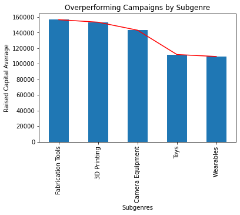

```python
i = {}

for col in subgenre.columns:
    i[col] = (data_pass.raised_cap[data_pass['sub_genre'] == col].sum() / len(data_pass.raised_cap[data_pass['sub_genre'] == col]))

raised_cap_prop = pd.DataFrame.from_dict(i, orient='index')
raised_cap_prop = raised_cap_prop.T.sort_values(by = 0, axis = 1, ascending = False)
raised_cap_prop = raised_cap_prop.T
raised_cap_prop = raised_cap_prop.rename(columns={0: "raised_cap_avg"})

raised_cap_prop.head().plot(kind = 'bar')
plt.plot(raised_cap_prop.head(), 'r')
plt.title("Overperforming Campaigns by Subgenre")
plt.legend().remove()
plt.xlabel("Subgenres")
plt.ylabel("Raised Capital Average")
plt.show()
```

A correlation heatmap can reveal some useful correlated variables for analysis. Unfortunately, there aren't that many positively correlated variables and the derived data such as creation time, etc has seemingly little effect on important variables such as success, backers_count, etc. For the most part, correlation is quite weak between variables. Variables such as raised_cap, goal_usd, and backers_count will still need to be analysed as they can answer the research questions motivating this coursework even though correlation is pretty weak.

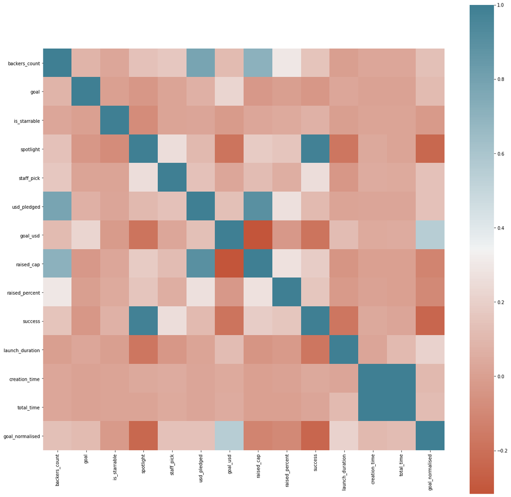

```python
import seaborn as sns
from sklearn.metrics import mean_squared_error, r2_score

data_numeric = data.select_dtypes(include = 'number')
data_numeric = data_numeric.drop(columns = ['converted_pledged_amount', 'fx_rate', 'id', 'pledged', 'static_usd_rate'])

corr = data_numeric.corr()

plt.figure(figsize = (20,20))
ax = sns.heatmap(corr, cmap=sns.diverging_palette(20, 220, n=200), square=True)
plt.show()
```

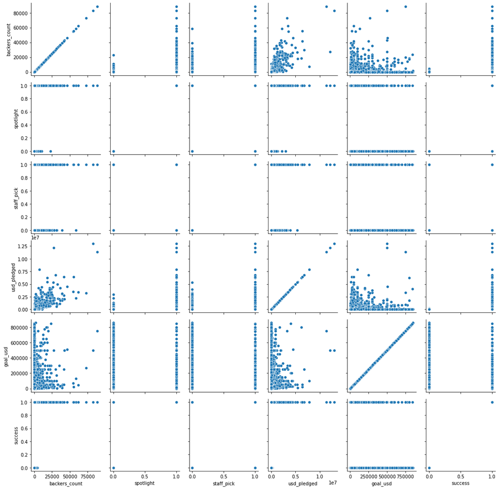

```python
g = sns.PairGrid(data_numeric.drop(columns = ['goal', 'is_starrable', 'goal_normalised', 'total_time', 'launch_duration', 'creation_time', 'raised_cap', 'raised_percent']))
g.map(sns.scatterplot)
```

```python
data_pass_numeric = data_pass.select_dtypes(include = 'number')
data_pass_numeric = data_pass_numeric.drop(columns = ['converted_pledged_amount', 'fx_rate', 'id', 'pledged', 'static_usd_rate'])
data_pass_num_fil = data_pass_numeric
data_pass_num_fil = data_pass_num_fil.drop(columns = ['goal', 'is_starrable', 'spotlight', 'staff_pick', 'success', 'goal_normalised', 'launch_duration', 'creation_time', 'total_time'])
```

A very messy joint plot between goal_usd and backers_count!

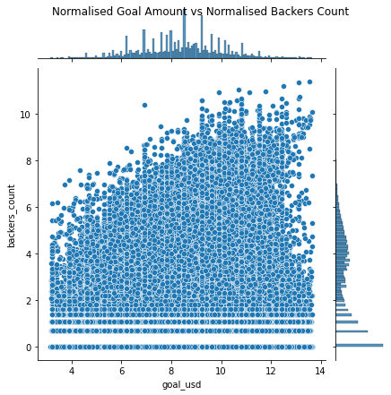

```python
temp = pd.DataFrame(data['goal_usd'])
temp['backers_count'] = data['backers_count']

temp = temp.transform(np.log)
temp = temp[np.isfinite(temp)]

ind_var = np.array(temp['goal_usd'])
dep_var1 = np.array(temp['backers_count'])

fig = sns.jointplot(x = ind_var, y = dep_var1)
fig.set_axis_labels('goal_usd', 'backers_count')
fig.fig.suptitle("Normalised Goal Amount vs Normalised Backers Count")
plt.show()
```

**Linear Regression**

Linear regression will be used to understand how the variables such as goal_usd, backers_count, and raised_cap affect each other. As seen in the heatmap earlier, the correlations are quite weak. However, regression analysis might prove to be useful.

The first regression is performed between goal_usd and backers_count. Unfortunately, the R2 is very low suggesting very low variance captured by the model. Pointless to continue the analysis when the R2 is only 0.02

```python
from sklearn.linear_model import LinearRegression

temp = pd.DataFrame(data['backers_count'])
temp['goal_usd'] = data['goal_usd']

temp['backers_norm'] = temp['backers_count'].transform(np.log)
temp['goal_usd'] = temp['goal_usd'].transform(np.log)
temp = temp[np.isfinite(temp)]
temp = temp.dropna()

model = LinearRegression()

model.fit(temp[['goal_usd']], temp['backers_norm'])
print('intercept:', model.intercept_)
print('slope:', model.coef_)

r_sq=model.score(temp[['goal_usd']], temp['backers_norm'])
print("R2=",r_sq)
```

```
intercept: 1.7888451437613446
slope: [0.17664947]
R2= 0.022155928356660026
```

As seen earlier in the distributions, backers_count is quite normally distributed only when the successful campaigns are considered. The previous model might be failing due to non-linearity and non-normality. A linear regression is done below using a subset of the data. Here an R2 of 0.47 can be observed which definitely warrants further investigation. The residual histogram is normally distributed but the mean is shifted to the left which isnt ideal. The mean squared error is quite high pointing to a weak model. The QQ plot of the residual is mostly normally distributed with most of the points on the normal line. Not an ideal fit. This investigation was carried out in the hopes to understand how a goal amount affects the number of backers. Does a high goal amount deter backers? The model seems to suggest that in the case when the camapigns ae successful, the goal amount does not seem to be an issue for the number of backers. This is to be expected and hardly surprising. A more interesting result would have been obtained if the entire dataset was used.

```
intercept: -0.5220357924533596
slope: [0.61064229]
R2= 0.4755971693269785
```

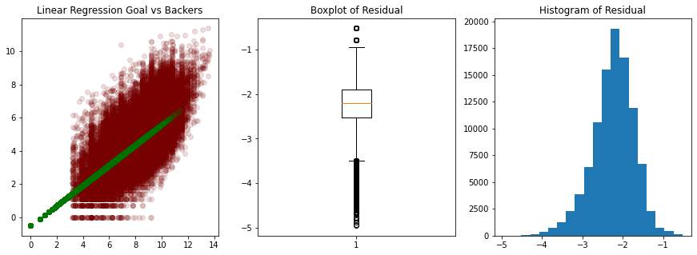

```
Mean Squared Error 5.278
Mean -2.238
Standard devation 0.520
Mean backers_count 4.406
Median backers_count 4.304
```

```python
temp = pd.DataFrame(data_pass['backers_count'])
temp['goal_usd'] = data_pass['goal_usd']

temp['backers_norm'] = temp['backers_count'].transform(np.log)
temp['goal_usd'] = temp['goal_usd'].transform(np.log)
temp = temp[np.isfinite(temp)]
temp = temp.dropna()

model = LinearRegression()

model.fit(temp[['goal_usd']], temp['backers_norm'])
print('intercept:', model.intercept_)
print('slope:', model.coef_)

r_sq=model.score(temp[['goal_usd']], temp['backers_norm'])
print("R2=",r_sq)

temp['pred'] = model.predict(temp[['backers_norm']])

temp['resid'] = temp['pred']-temp['backers_norm']

fig, axis = plt.subplots(1, 3, figsize=(15, 5))
axis[0].scatter(temp['goal_usd'], temp['backers_norm'],c="#77000022")
axis[0].scatter(temp['backers_norm'], temp['pred'],c="#00770022")
axis[0].set_title('Linear Regression Goal vs Backers')
axis[1].boxplot(temp['resid'])
axis[1].set_title('Boxplot of Residual')
axis[2].hist(temp['resid'],bins=20)
axis[2].set_title('Histogram of Residual')
plt.show()

print("Mean Squared Error {:.3f}".format(mean_squared_error(temp['backers_norm'], temp['pred'])))
print("Mean {:.3f}".format(temp['resid'].mean()))#More readable number
print("Standard devation {:.3f}".format(temp['resid'].std()))#More readable number
print("Mean backers_count {:.3f}".format(temp['backers_norm'].mean()))
print("Median backers_count {:.3f}".format(temp['backers_norm'].median()))
```

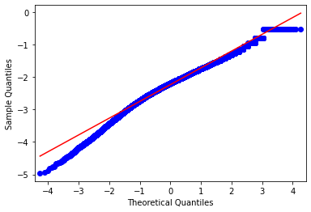

```python
fig = sm.qqplot(temp['resid'], stats.norm, line = 'r')
plt.show()
```

```python
temp = pd.DataFrame(data['raised_cap'])
temp['goal_usd'] = data['goal_usd']

model = LinearRegression()

model.fit(temp[['goal_usd']], temp['raised_cap'])
print('intercept:', model.intercept_)
print('slope:', model.coef_)

r_sq=model.score(temp[['goal_usd']], temp['raised_cap'])
print("R2=",r_sq)
```

```
intercept: 8629.49997150835
slope: [-0.71373779]
R2= 0.1002281662831146
```

```
intercept: 0.8814780598844782
slope: [0.70850587]
R2= 0.21581457563016015
```

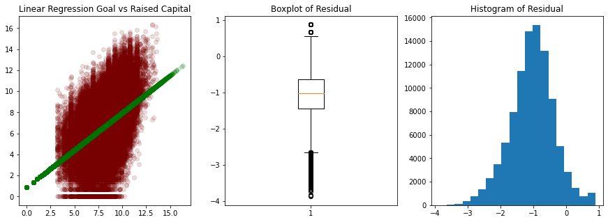

```
Mean Squared Error 1.545
Mean -1.048
Standard devation 0.669
Mean backers_count 6.619
Median backers_count 6.516
```

```python
temp = pd.DataFrame(data['raised_cap'])
temp['goal_usd'] = data['goal_usd']

temp['raised_cap'] = temp['raised_cap'].transform(np.log)
temp['goal_usd'] = temp['goal_usd'].transform(np.log)
temp = temp[np.isfinite(temp)]
temp = temp.dropna()

model = LinearRegression()

model.fit(temp[['goal_usd']], temp['raised_cap'])
print('intercept:', model.intercept_)
print('slope:', model.coef_)

r_sq=model.score(temp[['goal_usd']], temp['raised_cap'])
print("R2=",r_sq)

temp['pred'] = model.predict(temp[['raised_cap']])

temp['resid'] = temp['pred']-temp['raised_cap']

fig, axis = plt.subplots(1, 3, figsize=(15, 5))
axis[0].scatter(temp['goal_usd'], temp['raised_cap'],c="#77000022")
axis[0].scatter(temp['raised_cap'], temp['pred'],c="#00770022")
axis[0].set_title('Linear Regression Goal vs Raised Capital')
axis[1].boxplot(temp['resid'])
axis[1].set_title('Boxplot of Residual')
axis[2].hist(temp['resid'],bins=20)
axis[2].set_title('Histogram of Residual')
plt.show()

print("Mean Squared Error {:.3f}".format(mean_squared_error(temp['raised_cap'], temp['pred'])))
print("Mean {:.3f}".format(temp['resid'].mean()))#More readable number
print("Standard devation {:.3f}".format(temp['resid'].std()))#More readable number
print("Mean backers_count {:.3f}".format(temp['raised_cap'].mean()))
print("Median backers_count {:.3f}".format(temp['raised_cap'].median()))
```

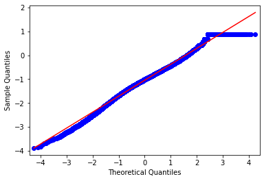

```python
fig = sm.qqplot(temp['resid'], stats.norm, line = 'r')
plt.show()
```

Similarly, the relationship between usd_pledged and goal_usd cannot be captured by the model due to low R2 value.

```python
temp = pd.DataFrame(data['usd_pledged'])
temp['goal_usd'] = data['goal_usd']

temp['usd_pledged'] = temp['usd_pledged'].transform(np.log)
temp['goal_usd'] = temp['goal_usd'].transform(np.log)
temp = temp[np.isfinite(temp)]
temp = temp.dropna()

model = LinearRegression()

model.fit(temp[['goal_usd']], temp['usd_pledged'])
print('intercept:', model.intercept_)
print('slope:', model.coef_)

r_sq=model.score(temp[['goal_usd']], temp['usd_pledged'])
print("R2=",r_sq)
```

```
intercept: 4.136492931710223
slope: [0.33921576]
R2= 0.03844362219808506
```

Again linear regression fails to capture any variance in the model to see relationship between launch duration and goal.

```python
temp = pd.DataFrame(data['launch_duration'])
temp['goal_usd'] = data['goal_usd']

temp['launch_duration'] = temp['launch_duration'].transform(np.log)
temp['goal_usd'] = temp['goal_usd'].transform(np.log)
temp = temp[np.isfinite(temp)]
temp = temp.dropna()

model = LinearRegression()

model.fit(temp[['goal_usd']], temp['launch_duration'])
print('intercept:', model.intercept_)
print('slope:', model.coef_)

r_sq=model.score(temp[['goal_usd']], temp['launch_duration'])
print("R2=",r_sq)
```

```
intercept: 2.90588295262234
slope: [0.06112733]
R2= 0.06340127361700498
```

An very boring analysis can be done with backers_count and raised_cap. It is common sense to know that the higher the number of backers the more a campaign can outperform. The model is quite good here but the high MSE remains a concern.

```
intercept: 0.551141798248902
slope: [1.36305376]
R2= 0.6100852471305784
```

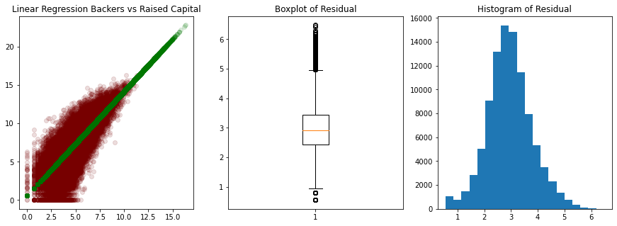

```
Mean Squared Error 9.421
Mean 2.954
Standard devation 0.833
Mean backers_count 6.619
Median backers_count 6.516
```

```python
temp = pd.DataFrame(data['raised_cap'])
temp['backers_count'] = data['backers_count']

temp['raised_cap'] = temp['raised_cap'].transform(np.log)
temp['backers_count'] = temp['backers_count'].transform(np.log)
temp = temp[np.isfinite(temp)]
temp = temp.dropna()

model = LinearRegression()

model.fit(temp[['backers_count']], temp['raised_cap'])
print('intercept:', model.intercept_)
print('slope:', model.coef_)

r_sq=model.score(temp[['backers_count']], temp['raised_cap'])
print("R2=",r_sq)

temp['pred'] = model.predict(temp[['raised_cap']])

temp['resid'] = temp['pred']-temp['raised_cap']

fig, axis = plt.subplots(1, 3, figsize=(15, 5))
axis[0].scatter(temp['backers_count'], temp['raised_cap'],c="#77000022")
axis[0].scatter(temp['raised_cap'], temp['pred'],c="#00770022")
axis[0].set_title('Linear Regression Backers vs Raised Capital')
axis[1].boxplot(temp['resid'])
axis[1].set_title('Boxplot of Residual')
axis[2].hist(temp['resid'],bins=20)
axis[2].set_title('Histogram of Residual')
plt.show()

print("Mean Squared Error {:.3f}".format(mean_squared_error(temp['raised_cap'], temp['pred'])))
print("Mean {:.3f}".format(temp['resid'].mean()))#More readable number
print("Standard devation {:.3f}".format(temp['resid'].std()))#More readable number
print("Mean backers_count {:.3f}".format(temp['raised_cap'].mean()))
print("Median backers_count {:.3f}".format(temp['raised_cap'].median()))
```

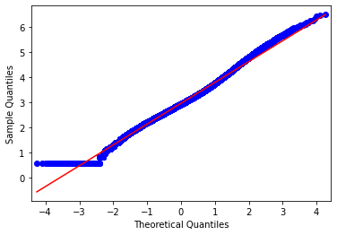

```python
fig = sm.qqplot(temp['resid'], stats.norm, line = 'r')
plt.show()
```

Linear regression analysis was ineffective in this analysis. Perhaps better transformation techniques could have yielded better results. Log transofrmations seem to be inadequate and research into other transformation techniques must be looked into for the future. Perhaps this technique is prone to failure in this analysis as the variables are extremely skewed, are non-normal (backers_count), and have low correlation. Alternative ML techniques can be looked into for better fit.

## 3. Predictive Modeling - Logistic Regression

For building a predictive model to accurately ascertain successful campaigns, this analysis will be looking at categorical variables. Logistic regression will be a very useful technique when it comes to categorical variables. Here, success is the label and interesting categorical variables will be used as data. This technique can showcase the impact categorical variables have on the success of a campaign. A very important point to note is that only certain variables are chosen for this analysis. The variables are known when the project is live. If a predictive model could be built just on such variables that are visible during the launch of a project, the effectiveness and usefulness of the model will increase. Due to complexity and computational limitations, locations of cities are not included as the data set becomes too massive and difficult to model.

```python
corr_success = corr[['success']]

corr_success = corr_success.sort_values(by ='success',ascending=False)

corr_success.T.head()
```

|  | success | spotlight | staff_pick | raised_cap | raised_percent | backers_count | usd_pledged | is_starrable | creation_time | total_time | goal | launch_duration | goal_usd | goal_normalised |
| --- | --- | --- | --- | --- | --- | --- | --- | --- | --- | --- | --- | --- | --- | --- |
| success | 1.0 | 0.98545 | 0.260768 | 0.184573 | 0.160723 | 0.144304 | 0.108518 | 0.072723 | 0.036563 | 0.021426 | -0.034127 | -0.173929 | -0.181977 | -0.238596 |

One-hot encoding technique will be used to transform the categorical variables into binary distributions. In the code below, dummy variables are obtained from interesting variables. All the dummy variables are then merged into a pandas dataframe for easy processing.

```python
from sklearn.model_selection import train_test_split
from sklearn.linear_model import LogisticRegression
from sklearn.metrics import classification_report
from sklearn.metrics import confusion_matrix
from sklearn.metrics import plot_confusion_matrix

location = pd.get_dummies(data['country'])
main_genre = pd.get_dummies(data['main_genre'])
sub_genre = pd.get_dummies(data['sub_genre'])
staff_pick = data['staff_pick']
success = data['success']

data_logreg = pd.concat([location, main_genre, sub_genre, staff_pick, success], axis = 1)
```

Splitting the dataset and building the model

```python
x_train_mod, x_test_mod, y_train_mod, y_test_mod = train_test_split(data_logreg.drop('success',axis=1), data_logreg['success'], test_size=0.33, random_state=42)

model_mod = LogisticRegression(max_iter = 1000)

model_mod.fit(x_train_mod,y_train_mod)

predic_mod = model_mod.predict(x_test_mod)
```

This model seems to be very promising! It has an accuracy score of 78% and can predict successes with 85% precision and failures with 72% precision. The model seems to predict successful campaigns quite well.

```python
print("=======================================================\n")
print(classification_report(y_test_mod,predic_mod))
print("=======================================================\n")

print('Accuracy of logistic regression classifier on modified test set: {:.2f}'.format(model_mod.score(x_test_mod, y_test_mod)))
```

```
=======================================================

              precision    recall  f1-score   support

         0.0       0.72      0.85      0.78     27287
         1.0       0.85      0.72      0.78     32761

    accuracy                           0.78     60048
   macro avg       0.79      0.79      0.78     60048
weighted avg       0.79      0.78      0.78     60048

=======================================================

Accuracy of logistic regression classifier on modified test set: 0.78
```

Confusion matrix for the modified model

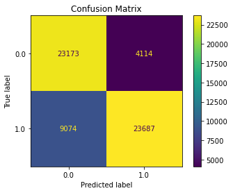

```python
fig = plot_confusion_matrix(model_mod, x_test_mod, y_test_mod)
fig.ax_.set_title("Confusion Matrix")
plt.show()
```

To understand the influence of variables on this model, coefficients must be looked at for analysis. Below, the positively influential and negatively influential variables are displayed. It seems that the influentail variables mostly belong to sub genres. This was seen before in the exploratory analysis with a few sub genre categories scoring a near 100 percent success. For curiosity, the influence of the staff pick variable can be seen in the next cell. It seems to be reasonably influential in the model but no where close to the subgenre variables.

```python
model_cols = pd.DataFrame(data_logreg.drop('success', axis = 1).columns)

coeff = pd.DataFrame(model_mod.coef_[0], columns = ['coefficient'])

model_cols = model_cols.rename(columns={0: "variables"})

pd_coeff = pd.concat([model_cols, coeff], axis = 1)

pd_coeff = pd_coeff.sort_values(by ='coefficient',ascending=False)

print("=====================================")
print("     Pos Influential Variables")
print("=====================================")
print(pd_coeff.head())
print("\n")
print("=====================================")
print("     Neg Influencial Variables")
print("=====================================")
print(pd_coeff.iloc[-5:])
```

```
=====================================
     Pos Influential Variables
=====================================
          variables  coefficient
39      Accessories     5.794869
98     Illustration     5.697370
138  Product Design     5.687625
153          Shorts     5.641011
71      Documentary     5.479547


=====================================
     Neg Influencial Variables
=====================================
              variables  coefficient
143                 R&B    -1.748844
88          Food Trucks    -1.789853
102  Interactive Design    -1.872261
111          Live Games    -2.466816
115        Mobile Games    -3.119606
```

```python
print("Staff Pick Influence\n")
print(pd_coeff[pd_coeff['variables'] == 'staff_pick'])
```

```
Staff Pick Influence

      variables  coefficient
183  staff_pick     2.236912
```

To better understand the logistic regression model, an ROC curve was plotted below. The ROC curve should deviate as much as it can from the normal line as can be seen in the plot. The plot suggests that the model is quite good at prediction and provides a visual display of that information.

```
ROC Score: 0.7861282814185031
```

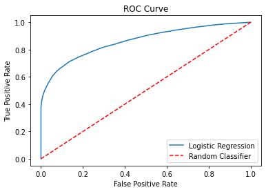

```python
from sklearn.metrics import roc_auc_score
from sklearn.metrics import roc_curve

logreg_roc_auc = roc_auc_score(y_test_mod, model_mod.predict(x_test_mod))
fpr, tpr, thresholds = roc_curve(y_test_mod, model_mod.predict_proba(x_test_mod)[:,1])

print("ROC Score: " + str(logreg_roc_auc) + "\n")

plt.figure()
plt.plot(fpr, tpr, label='Logistic Regression')
plt.plot([0, 1], [0, 1],'r--', label='Random Classifier')
plt.legend()
plt.xlabel('False Positive Rate')
plt.ylabel('True Positive Rate')
plt.title('ROC Curve')
plt.show()
```

## 4. References

https://seaborn.pydata.org/tutorial/axis_grids.html

https://pandas.pydata.org/pandas-docs/stable/index.html

https://stackoverflow.com/questions/31111032/transform-a-counter-object-into-a-pandas-dataframe

https://towardsdatascience.com/logistic-regression-a-simplified-approach-using-python-c4bc81a87c31

https://towardsdatascience.com/building-a-logistic-regression-in-python-step-by-step-becd4d56c9c8

https://stackoverflow.com/questions/52670012/convergencewarning-liblinear-failed-to-converge-increase-the-number-of-iterati

https://en.wikipedia.org/wiki/Receiver_operating_characteristic

Lab Feedback Jupyter Notebooks